# Research project 1

Manuel Estevez R

09/06/2020

## Load and Explore/process the data

```r
library(ggplot2)
actividades<-read.csv("data_activity/activity.csv")
dim(actividades)
```

```
## [1] 17568     3
```

```r
names(actividades)
```

```
## [1] "steps"    "date"     "interval"
```

```r
head(actividades)
```

```
##   steps       date interval
## 1    NA 2012-10-01        0
## 2    NA 2012-10-01        5
## 3    NA 2012-10-01       10
## 4    NA 2012-10-01       15
## 5    NA 2012-10-01       20
## 6    NA 2012-10-01       25
```

```r
str(actividades)
```

```
## 'data.frame':    17568 obs. of  3 variables:
##  $ steps   : int  NA NA NA NA NA NA NA NA NA NA ...
##  $ date    : chr  "2012-10-01" "2012-10-01" "2012-10-01" "2012-10-01" ...
##  $ interval: int  0 5 10 15 20 25 30 35 40 45 ...
```

```r
sum(is.na(actividades$steps))/dim(actividades)[[1]]
```

```
## [1] 0.1311475
```

```r
library(lubridate)
actividades$date<-ymd(actividades$date)
length(unique(actividades$date))
```

```
## [1] 61
```

## Histogram of the total number of steps taken each day

1. Calculate the total number of steps taken per day
2. Make a histogram of the total number of steps taken each day
3. Calculate and report the mean and median total number of steps taken per day

```r
pasospordias<-aggregate(actividades$steps,list(actividades$date), FUN=sum)
colnames(pasospordias)<-c("Date","Steps")
pasospordias
```

```
##          Date Steps
## 1  2012-10-01    NA
## 2  2012-10-02   126
## 3  2012-10-03 11352
## 4  2012-10-04 12116
## 5  2012-10-05 13294
## 6  2012-10-06 15420
## 7  2012-10-07 11015
## 8  2012-10-08    NA
## 9  2012-10-09 12811
## 10 2012-10-10  9900
## 11 2012-10-11 10304
## 12 2012-10-12 17382
## 13 2012-10-13 12426
## 14 2012-10-14 15098
```

[output cut: 47 more lines]

Histogram

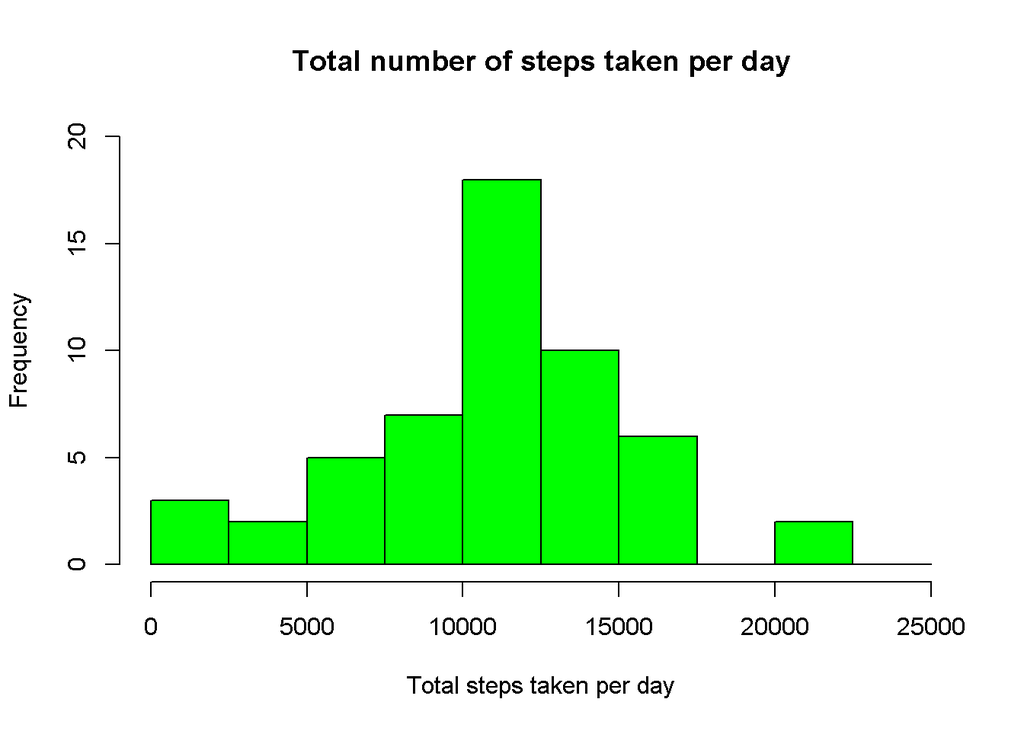

```r
hist(pasospordias$Steps, main = "Total number of steps taken per day", xlab = "Total steps taken per day", col = "green", ylim = c(0,20), breaks = seq(0,25000, by=2500))
```

# Mean and Median

```r
media<-mean(pasospordias$Steps, na.rm=TRUE)
media
```

```
## [1] 10766.19
```

```r
mediana<-median(pasospordias$Steps, na.rm=TRUE)
mediana
```

```
## [1] 10765
```

## Average daily activity pattern

1. Make a time series plot (i.e type= “𝚕”) of the 5-minute interval (x-axis) and the average number of steps taken, averaged across all days (y-axis)
2. Which 5-minute interval, on average across all the days in the dataset, contains the maximum number of steps?

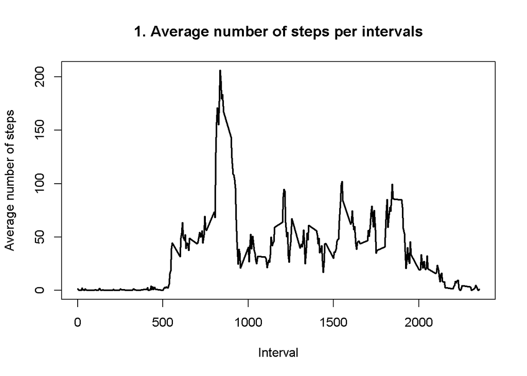

```r
promedioactividad<-aggregate(actividades$steps, by = list(actividades$interval), FUN=mean, na.rm=TRUE )
names(promedioactividad) <- c("Interval", "Mean")
plot(promedioactividad$Interval, promedioactividad$Mean, type = "l", col="black", lwd = 2, xlab="Interval", ylab="Average number of steps", main="1. Average number of steps per intervals")
```

```r
intervalmax<-promedioactividad[which.max(promedioactividad$Mean), ]$Interval
intervalmax
```

```
## [1] 835
```

## Missing Values

There are a number of days/intervals where there are missing values (coded as NA). The presence of missing days may introduce bias into some calculations or summaries of the data.

1. Calculate and report the total number of missing values in the dataset (i.e. the total number of rows with NAs)

```r
perdidos<-sum(is.na(actividades$steps))
```

Missing Steps 2304.

2. Devise a strategy for filling in all of the missing values in the dataset. The strategy does not need to be sophisticated. For example, you could use the mean/median for that day, or the mean for that 5-minute interval, etc.

```r
llenarpasos<-promedioactividad$Mean[match(actividades$interval,promedioactividad$Interval)]
```

3. New Dataset that is equal to the original dataset but with the missing data filled in.

```r
actividadesllenadas <- transform(actividades, steps = ifelse(is.na(actividades$steps), yes = llenarpasos, no = actividades$steps))
total_llenadas<- aggregate(steps ~ date, actividadesllenadas, sum)
names(total_llenadas) <- c("date", "daily_steps")
head(total_llenadas)
```

```
##         date daily_steps
## 1 2012-10-01    10766.19
## 2 2012-10-02      126.00
## 3 2012-10-03    11352.00
## 4 2012-10-04    12116.00
## 5 2012-10-05    13294.00
## 6 2012-10-06    15420.00
```

Histogram of the total number of steps taken each day and Calculate and report the mean and median total number of steps taken per day.

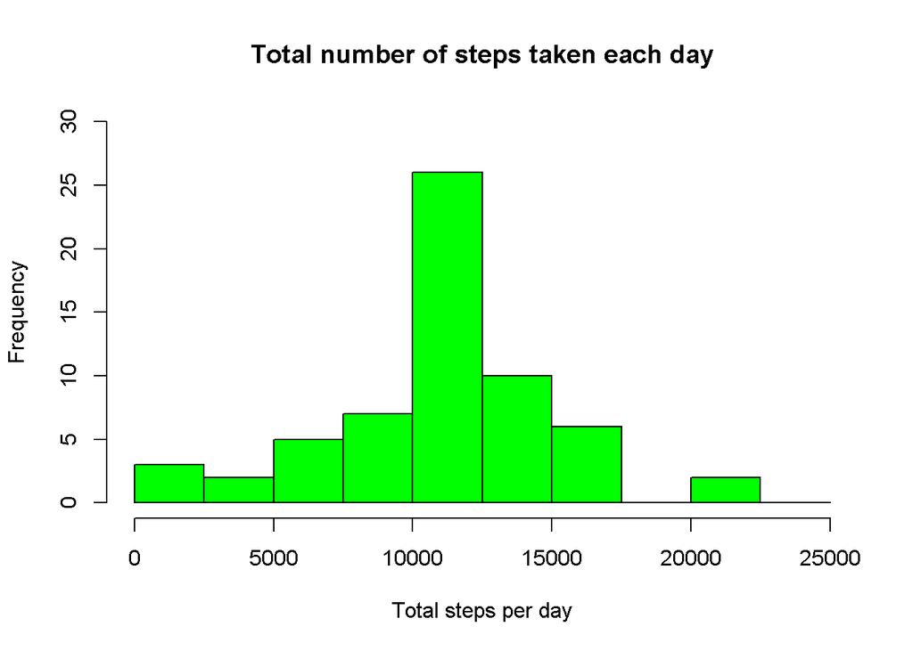

```r
hist(total_llenadas$daily_steps, col = "green", xlab = "Total steps per day", ylim = c(0,30), main = "Total number of steps taken each day", breaks = seq(0,25000,by=2500))
```

```r
mediallenadas<-mean(total_llenadas$daily_steps)
medianallenadas<-median(total_llenadas$daily_steps)
mediallenadas
```

```
## [1] 10766.19
```

```r
medianallenadas
```

```
## [1] 10766.19
```

## Are there differences in activity patterns between weekdays and weekends?

1. Create a new factor variable in the dataset with two levels - “weekday” and “weekend” indicating whether a given date is a weekday or weekend day.

```r
library(dplyr)
actividadesllenadas$date<-as.Date(actividadesllenadas$date)
head(actividadesllenadas$date)
```

```
## [1] "2012-10-01" "2012-10-01" "2012-10-01" "2012-10-01" "2012-10-01"
## [6] "2012-10-01"
```

```r
head(actividadesllenadas)
```

```
##       steps       date interval
## 1 1.7169811 2012-10-01        0
## 2 0.3396226 2012-10-01        5
## 3 0.1320755 2012-10-01       10
## 4 0.1509434 2012-10-01       15
## 5 0.0754717 2012-10-01       20
## 6 2.0943396 2012-10-01       25
```

```r
actividadesll2<-actividadesllenadas%>%
  mutate(dateType=ifelse(weekdays(actividadesllenadas$date)=="sábado" | weekdays(actividadesllenadas$date)=="domingo", "Weekend","Weekday"))
head(actividadesll2)
```

```
##       steps       date interval dateType
## 1 1.7169811 2012-10-01        0  Weekday
## 2 0.3396226 2012-10-01        5  Weekday
## 3 0.1320755 2012-10-01       10  Weekday
## 4 0.1509434 2012-10-01       15  Weekday
## 5 0.0754717 2012-10-01       20  Weekday
## 6 2.0943396 2012-10-01       25  Weekday
```

```r
actividadesfecha<- aggregate(steps~interval + dateType, actividadesll2, mean, na.rm = TRUE)
head(actividadesfecha)
```

```
##   interval dateType      steps
## 1        0  Weekday 2.25115304
## 2        5  Weekday 0.44528302
## 3       10  Weekday 0.17316562
## 4       15  Weekday 0.19790356
## 5       20  Weekday 0.09895178
## 6       25  Weekday 1.59035639
```

2.Make a panel plot containing a time series plot (i.e. 𝚝𝚢𝚙𝚎 = “𝚕”) of the 5-minute interval (x-axis) and the average number of steps taken, averaged across all weekday days or weekend days (y-axis)

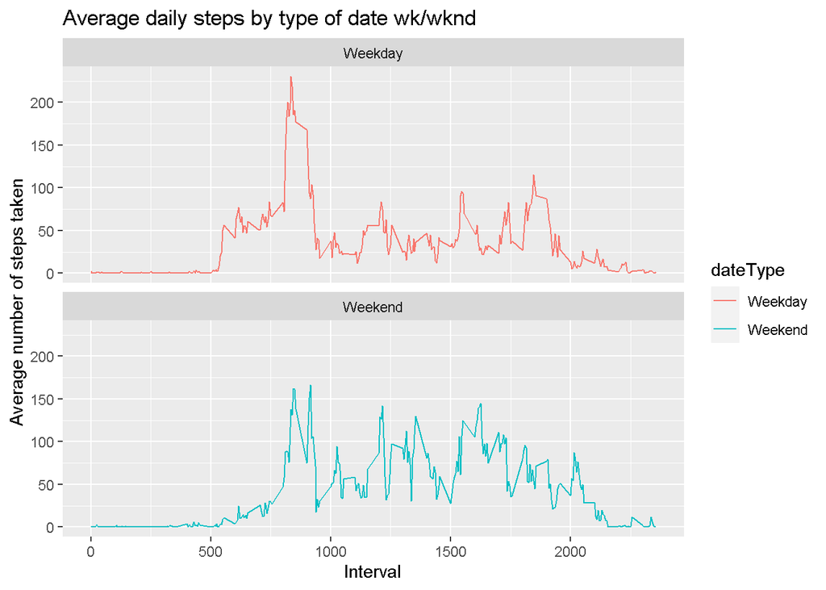

```r
plot<- ggplot(actividadesfecha, aes(x = interval , y = steps, color = dateType)) +
       geom_line() +
       labs(title = "Average daily steps by type of date wk/wknd", x = "Interval", y = "Average number of steps taken") +
       facet_wrap(~dateType, ncol = 1, nrow=2)
print(plot)
```